# NYC Citi Bikes

Jerry Balloch

[figure not shown]

image credit: citibike

# 1. Introduction

#### Domain knowledge (1.1)

Citi Bike is a bike share system in New York. It launched in May 2013 and has become an essential part of the city’s transport network. It is available to use 24/7, 365 day a year with over 20,000 bikes available to rent from stations across the city. Customers can choose to buy a single ride, a day pass or, or to subscribe to an annual pass, all through the Citi Bike app or the website.

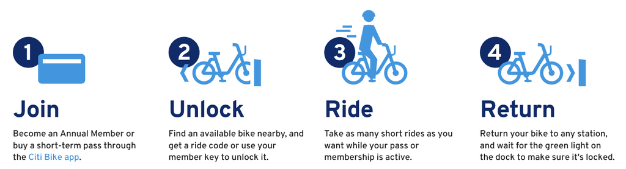

#### Business requirements (1.2)

This report looks at bike hire data from 2018. It helps to understand:

- What is the pattern of bike hires over time?
- Do bike hire patterns differ between bike rider demographics?
- What is the geographical spread of the start points of bike hires?

#### Business processes and data flow (1.3)

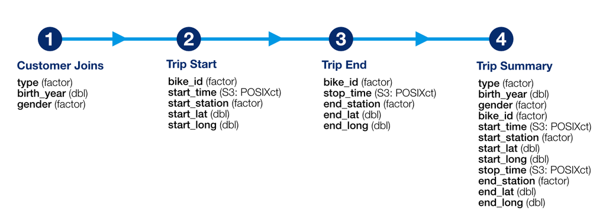

#### Data visualisation as a tool for decision-making (1.4)

The report looks to identify any trends in bike hires over the period which can then be used to inform future decisions on things like station locations, targeting who is hiring bikes, and making sure bikes are at stations that have a high demand.

#### Data types (1.5)

The dataset is made up of a different variables such as factors, datetimes, doubles, integers, dates, ordinals and durations.

- A datetime variable contains date and time parts stored as calendar date and time of day. You can select how precisely a datetime value is stored.
- An Ordinal variable is a categorical, statistical data type which has a natural ordered category, the distances between which are unknown.
- Integers are numbers which are not a fraction ie. a whole number.

#### Data quality and data bias (1.6)

The dataset looks to be centred around Jersey City not across the whole of NYC. There is a big bias in gender, 3069 Males to 930 Females and 269 unknown. Birth year spans 1887(!) to 1999 so a wide range of ages are represented - I decided to limit the age range to a maximum of 100 for this analysis. When looking at trip lengths there were a few excessively long durations so you will see that I have capped trip duration accordingly.

From an ethical point of view there is no way of identifying individuals in the dataset other than gender and birth year. Trip data is limited to start and stop points and times, no route information is provided again protecting individuals privacy.

# 2. Data cleaning

The dataset we are dealing with here comes from NYC Citi Bike and ranges from January 2018 to December 2018. I pulled time specific details like Year, Month and Day from the start_time column. I generated trip durations by minusing stop_times from start_times. Age was calculated by taking birth year away from the current year. Finally I counted the number of trips originating from each start station.

# 3. Data visualisation

I started off looking at the number of trips taken over the year before drilling down further to trips by day of the week. I also looked at the type of trip ie. subscriber or “customer” based. Gender and age splits were another consideration along with trip length. Finally I looked at station location and the number of trips originating there.

### Number of trips taken in 2018

The chart below shows how many trips were taken in throughout 2018. We can see that Spring to Autumn is the busiest time for bike hire, with the summer months being the peak. *This identifies peak periods, and how seasons effect bike hire so the business can make sure there are enough bikes to meet demand.*

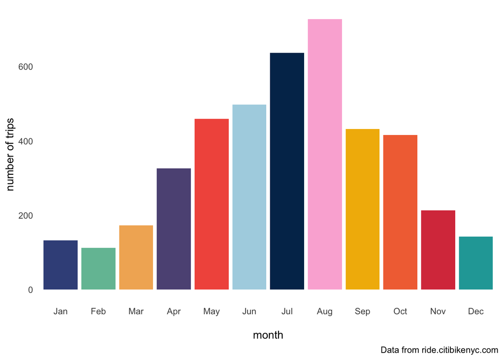

If we look at the number of trips across the year by day of the week we can see a fairly even spread of use throughout the week with the weekends being lower, especially Sundays. Tuesday appears to be the busiest day of the week for bike hires.

A steady supply of bikes Monday to Friday should help to continue this. Sundays could be a good day to perform any maintenance on the bikes as demand seems to be lower in general. *Sundays also could be a good day to have some kind of promotion running to try to up hires on that day.*

### Daily Citi Bike trips for 2018

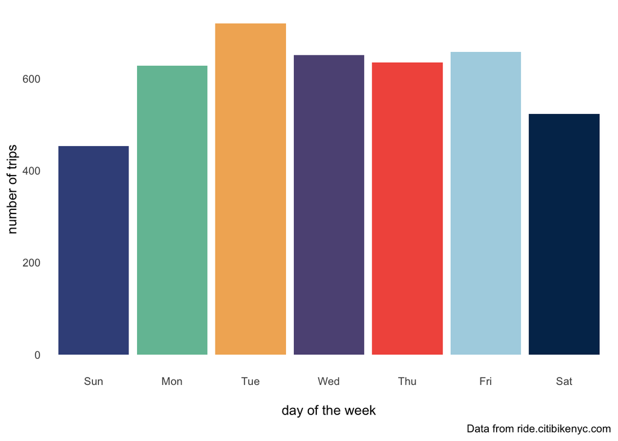

Looking at the chart below we can see that the type of trip shows us that the service is heavily used by subscribers as opposed to “customers” which could be more like day trippers or visitors to the city. *Could more be done to increase the uptake of bike hires for non-customers? Perhaps getting more visitors to the city onboard. Targeted advertising in travel magazines or at airports/train stations may help.*

### Type of trips

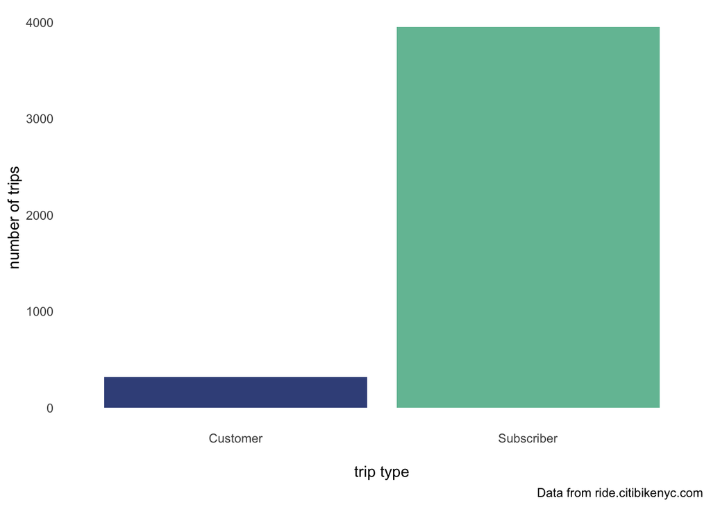

### Gender split

The chart below shows trip breakdown by gender. There are far more **men (3069)** using the service than **women (930)**. Does this reflect the wider population of NYC or does more need to be done to get more women to use the bikes. *Identifying the difference in bike hire between genders can give an insight into where to focus further advertising campaigns.*

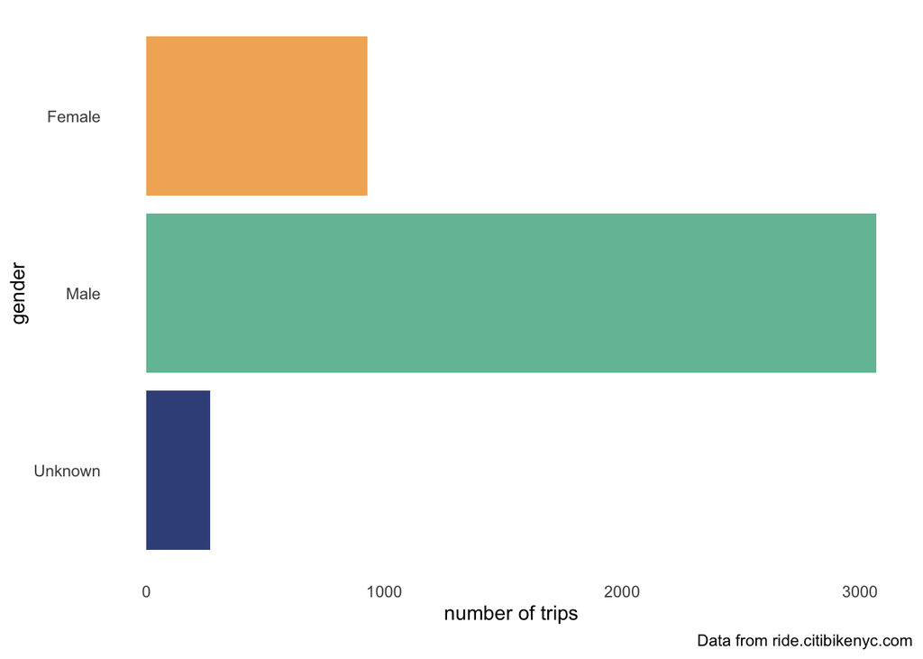

### Age and gender split

If we look further into the data we can see the age range and gender split alongside the duration of trips taken. There are a few outliers (trips with durations way longer than average) here, so on the other graph below I filtered the trip duration down to a maximum of 60 minutes to get a better picture of what is going on.

### Trip duration by age and gender

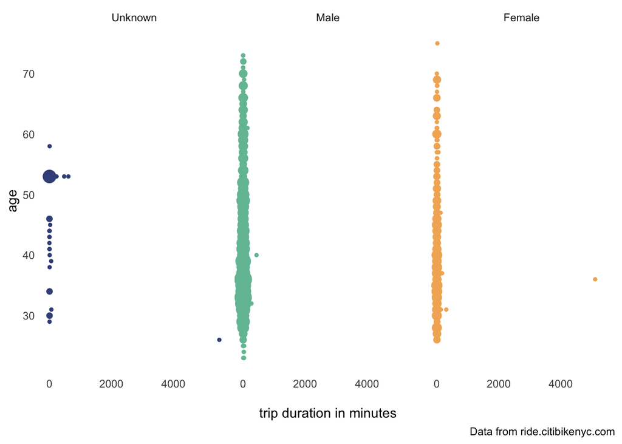

The chart below is the filtered chart. As you can see the trip duration has been limited to a maximum of 60 minutes. There were longer trips in the data but in general most trips were below 60 minutes.

We can see that the majority of women riders are below 50, while the majority of male riders seem to be below 65. The average trip length of around 12 minutes is highlighted by the vertical red line. *Finding out about trip duration is useful as it shows the movement and trip length of bikes between the stations and how quickly restocking each station could help to maintain a steady supply.*

### Trip duration limited to 60 minutes

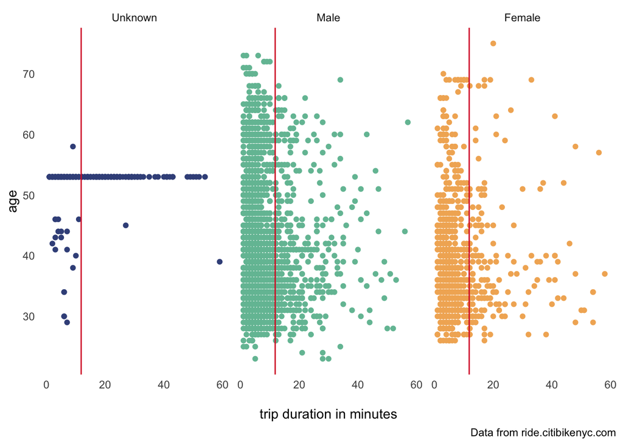

### Station Locations

The map below shows the location of Citi Bike stations from the dataset. The larger the dot, the more trips have originated there. Clicking on a dot will give you the Station ID and the number of trips that originated there. The busiest Station on our map is 3186 on Grove Street Path which had a total of 434 journeys start there.

*Focusing on high traffic areas could give an insight into where to place more bikes to maximise the amount of hires. It may be worth looking at Stations that don’t perform well and evaluating if it is worth keeping them or if some local advertising or such could help to increase hires there.*

[interactive chart not shown]

# 4. Conclusion

The Citi Bike scheme appears to be well used throughout the year. It is especially busy during the summer months. Making sure bikes are in good shape and enough are available in the summer can help maintain this busy time. The service seems to be heavily used by subscribers with nowhere near as many trips being taken by customers/non-subscribers. Could more be done to increase non subscriber use? Perhaps focusing on tourists could get non subscriber figures up.

There is almost a 3 to 1 ratio of Male to Female use of the service. What can be done to encourage more women to use hire bikes? There seems to be a good age range using the service but again less older women appear to be hiring, what could be done there?

Looking at the geographical spread, seeing stations mapped out and their popularity calculated, it shows where the volume of bikes needs to be to maintain the level of service needed. Perhaps looking at less used stations in more detail could identify why they are not being used as much and determine what could be done to increase uptake there.

#### Other considerations

Further analysis on bike hires by time of day could give more insight into usage and demand across the network.

It would also be interesting to look at data since the pandemic to see if people’s use of public transport has changed and more people are using the bike service.

[figure not shown]